# Predicting Hurricane Deaths

May 13th, 2020

## Purpose

- To predict the number of hurricane deaths
  - Using variables such as maximum sustained wind speed, atmospheric pressure, and property damage
- Hypothesis:
  - The number of deaths would *increase* with an increase in maximum sustained wind speed and property damage.
  - Intuitively it would make sense for more destructive hurricanes to also be more deadly.

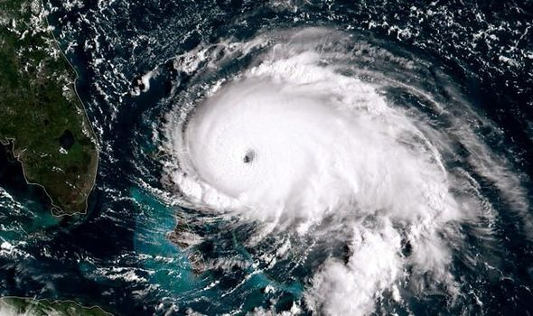

## Data

## Source

- Dataset “hurricNamed” from the “DAAG” R package
  - 94 named US hurricanes from 1950 to 2012
  - Includes: number of deaths, damage, weather statistics
  - Cited by a research paper

[figure not shown]

## Variables:

**Response Variable**

- `deaths` describes the number of human deaths that occurred due to each hurricane (ranging from 0 to 1846).

**Explanatory Variables**

- `LF.WindsMPH`: max wind speed (mph)
- `LF.PressureMB`: atmospheric pressure (millibars)
- `LF.times`: number of times the hurricane made landfall
- `BaseDam2014`: property damage (millions of 2014 US dollars)
- `NDAM2014`: normalized damage (millions of 2014 US dollars)

## Exploratory Analysis

## Kernel Density Estimation

- `deaths`, `NDAM2014`, and `BaseDam2014` had very skewed kernel density estimates.
- Adding a `log()` transformation to `deaths`, `NDAM2014`, and `BaseDam2014` resulted in more normal kernel density estimates and minimized the effects of the outliers.

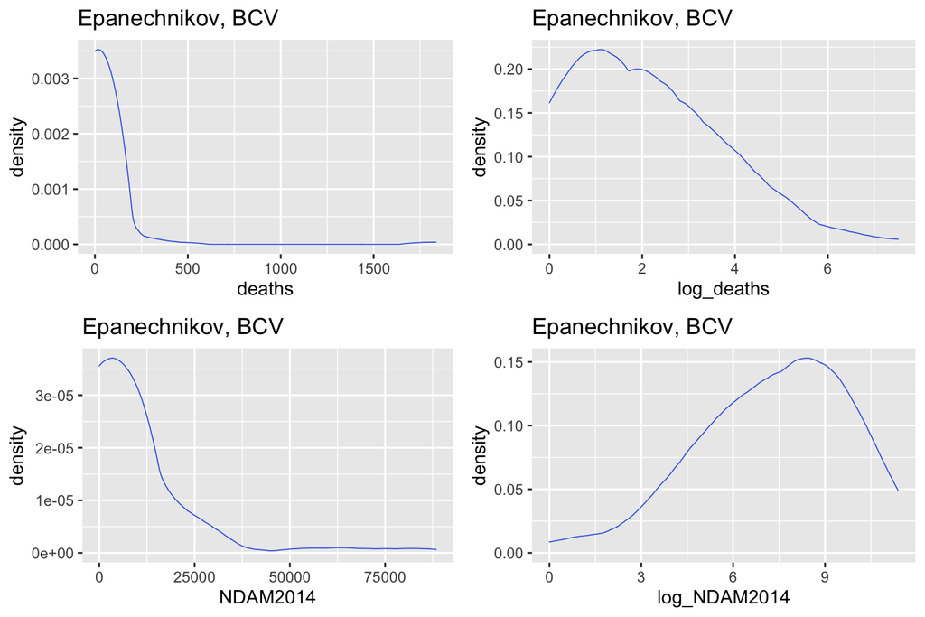

## Correlation Tests

- We use Kendall’s \(\tau\) at a significance level \(\alpha=0.05\)
- Hypotheses tested:
  - The null hypothesis of no association (independence) \(H_0: \tau \leq 0\)
  - The alternative hypothesis of positive association \(H_A: \tau > 0\).
  - (We also tested for negative associations with the set of hypotheses \(H_0: \tau \geq 0\) and \(H_A: \tau < 0\).)

## Correlation Table

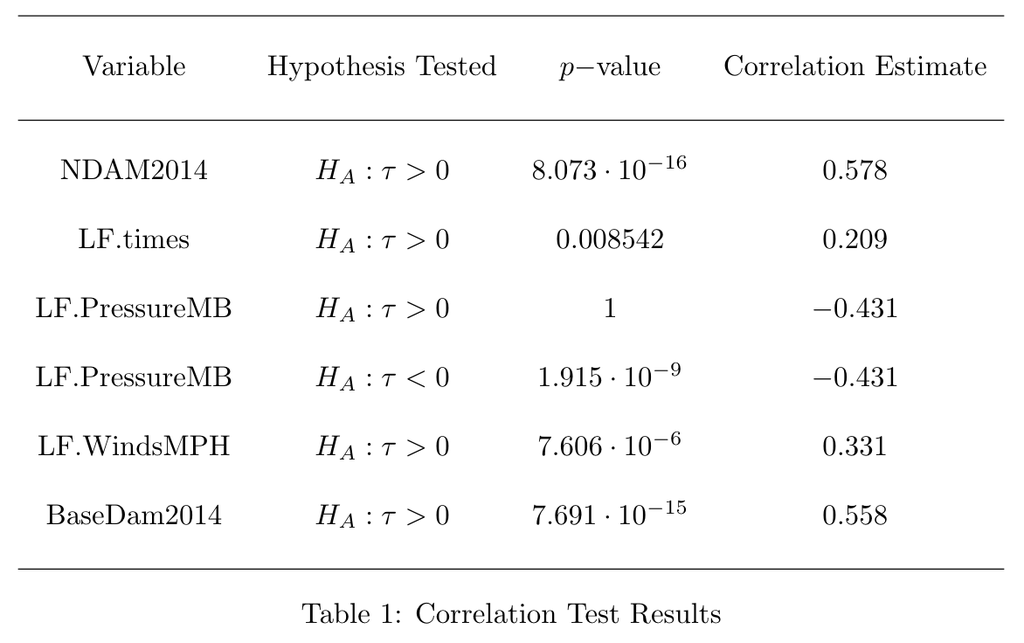

## Model Fitting

## Ordinary Least Squares Regression

- Carried out best subsets selection method and series of nested F tests
- Assumptions for OLS:
  - Independence
  - Linearity & Equal Variances
  - Normality of Residuals

## Best OLS model

- The best OLS model was the model predicting `log_deaths` with simply `log_NDAM2014` (normalized damage)
- AIC = 301.11, and \(R^2_{adj}\) = 50.08%.

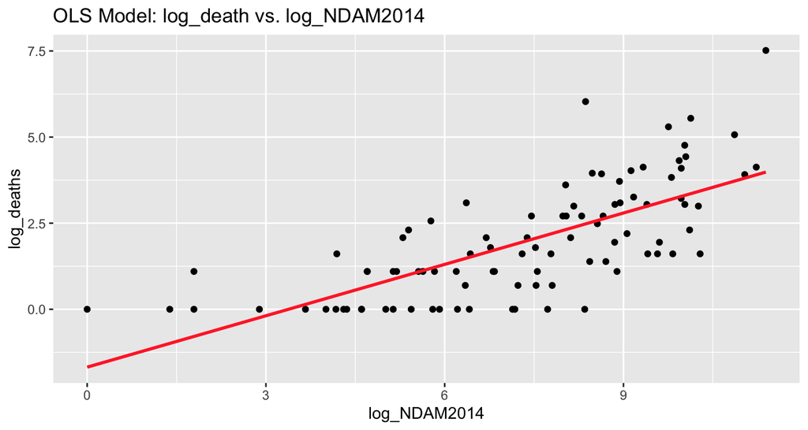

## OLS Residuals vs. Fitted

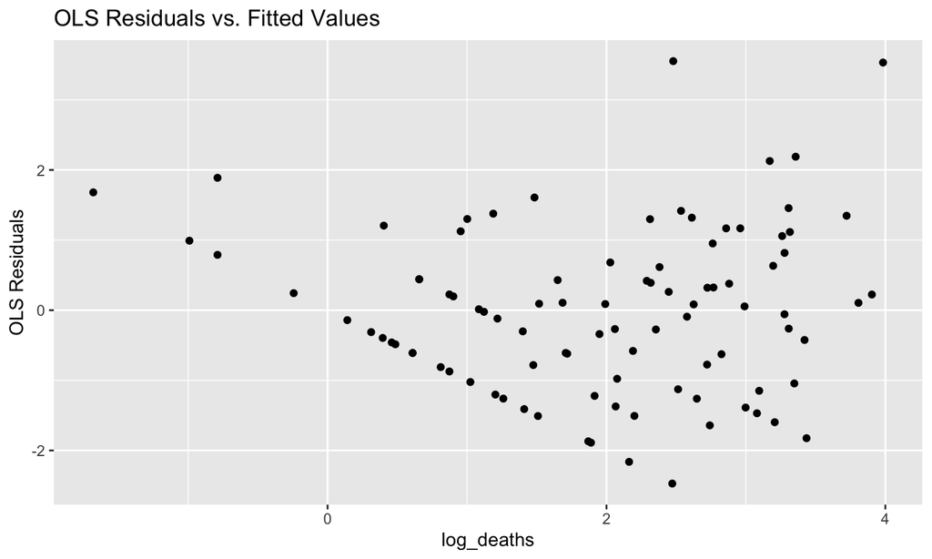

## Kolmogorov-Smirnov Test

- Ran this test to check the assumption of normally distributed residuals for our above selected linear regression model.
- Hypothesis: \[H_0: F(t) = F^*(t) \\ H_A: F(t) \neq F^*(t) \,\, \text {for at least one} \,\, t\] Where \(F(t)\) refers to the estimated CDF of the distribution of residuals of our linear model, and \(F^*(t)\) is the CDF of the normal distribution.

## Kolmogorov-Smirnov Test Results

- \(p-\)value of \(0.7095 > 0.05\)

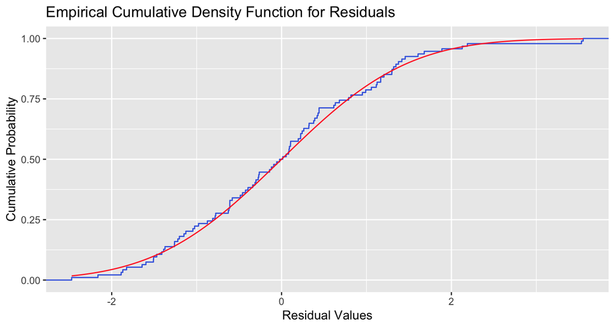

## Best JHM Model

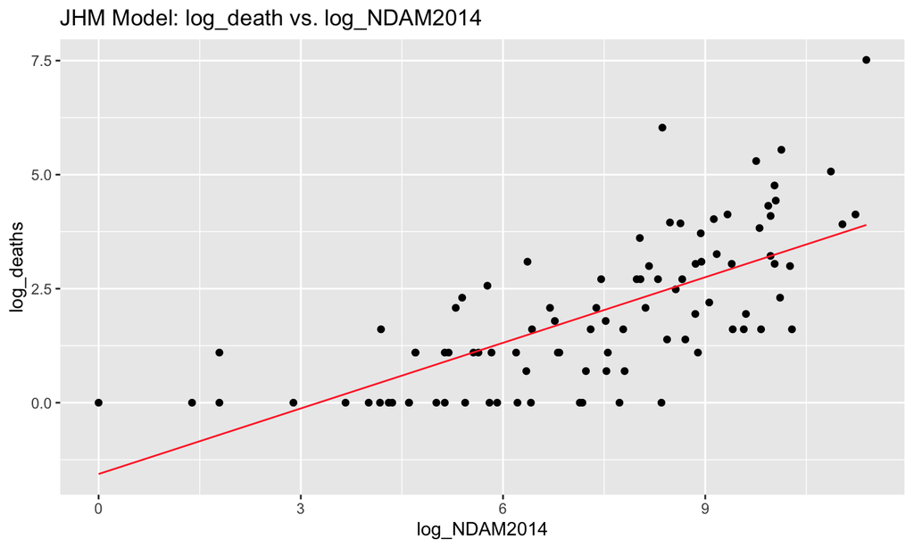

## JHM Residuals vs. Fitted

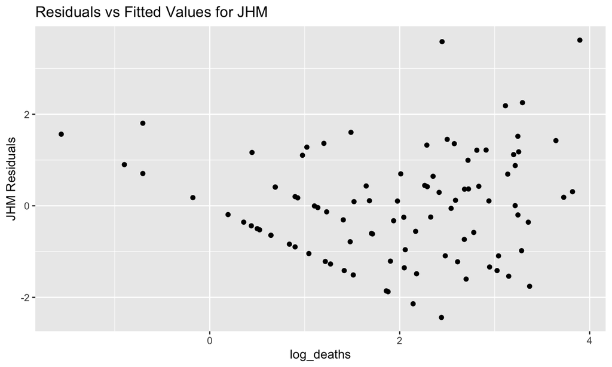

## Generalized Additive Model

## Fitting log_NDAM2014 & LF.PressureMB to the GAM

- GAM used to look for possible trends and relationships that were missed by other models primarily due to restrictions by linearity.
- Used manual forward selection to fit the best model.
- The best way to fit `log_NDAM2014` was with a b-spline.
- The best way to fit `LF.PressureMB` was with an s-spline (while keeping the previous b-spline for `log_NDAM2014`).
  - \(AIC = 288.015\)

## Additional Changes to the GAM

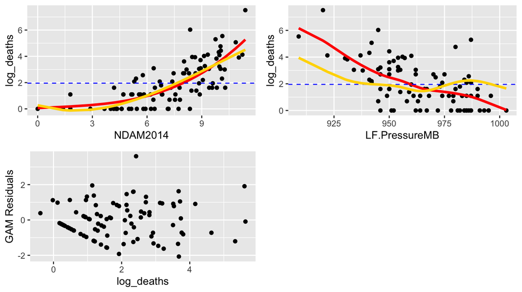

- After plotting, the `LF.PressureMB` scatterplot displayed a poor fit. (\(AIC=288.015\))

## Final GAM Model

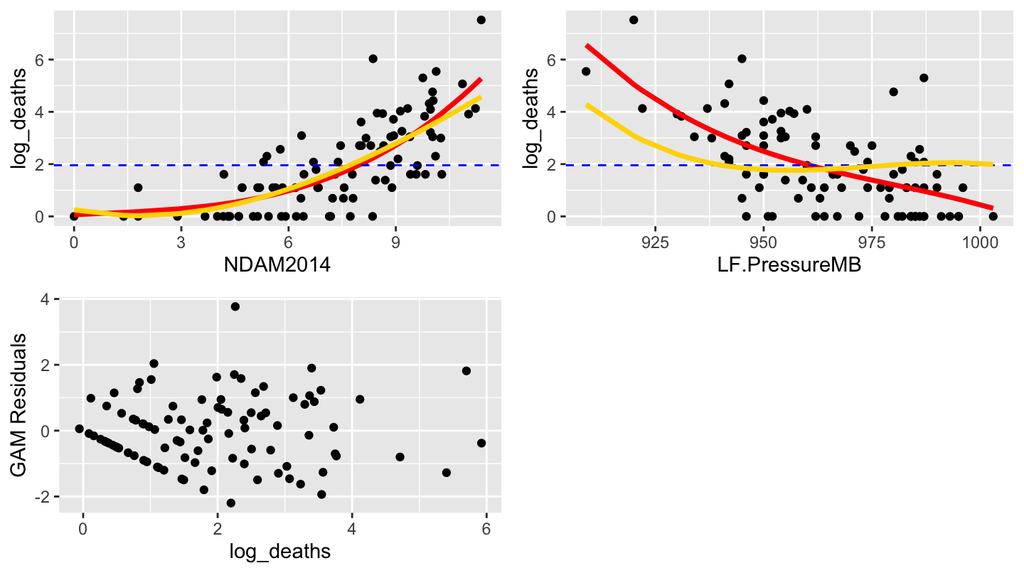

## Conclusion

## Comparison of Residuals

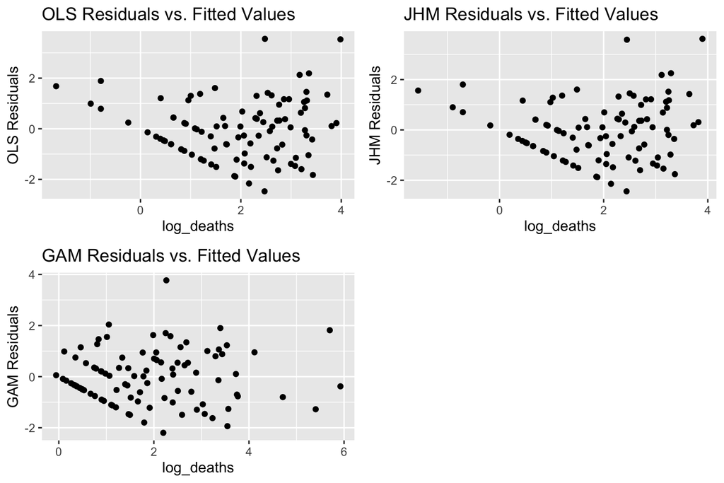

## Comparison of Fit

|  | \(R^2\) | \(R^2_{adj}\) | \(L1_{prop}\) |
| --- | --- | --- | --- |
| Best OLS | 0.5061 | 0.5008 | 0.3195 |
| Best JHM | 0.5054 | 0.5000 | 0.3183 |
| Best GAM | 0.6018 | 0.5743 | 0.3781 |

## Comparison of Fit cont’d

|  | CV \(R^2\) | CV \(R^2_{adj}\) | CV \(L1_{prop}\) |
| --- | --- | --- | --- |
| Best OLS | 0.4870 | 0.4814 | 0.3083 |
| Best JHM | 0.4867 | 0.4811 | 0.3027 |
| Best GAM | 0.5203 | 0.4872 | 0.3193 |

## Findings

- `gam(log_deaths ~ bs(log_NDAM2014) + poly(LF.PressureMB, 3))`
  - Low AIC = \(290.884\)
  - Better graphical representation
  - Higher \(R^2\), \(R^2_{adj}\), \(L1_{prop}\)
  - Ability to fit local trends
- Matches original hypothesis
  - More severe hurricane = more deaths

## Limitations

- Limited numerical predictors
- Reliance on normalized hurricane damage (`NDAM2014`)
- Reliance on log transformations
  - Potential for better log transformations

## References

- https://www.rdocumentation.org/packages/DAAG/versions/1.24
- https://www.pnas.org/content/111/24/8782#ref-28
- https://ascelibrary.org/doi/abs/10.1061/(ASCE)1527-6988(2008)9:1(29)
- https://www.rhinobldg.com/understanding-barometric-pressure-in-hurricanes/